# Prediction on Weight Lifting Exercise Dataset

Shubham Agrawal

26 October 2018

## Introduction

Using devices such as Jawbone Up, Nike FuelBand, and Fitbit it is now possible to collect a large amount of data about personal activity relatively inexpensively. These type of devices are part of the quantified self movement – a group of enthusiasts who take measurements about themselves regularly to improve their health, to find patterns in their behavior, or because they are tech geeks. One thing that people regularly do is quantify how much of a particular activity they do, but they rarely quantify how well they do it. In this project, our goal will be to use data from accelerometers on the belt, forearm, arm, and dumbell of 6 participants. They were asked to perform barbell lifts correctly and incorrectly in 5 different ways. More information is available from the website here: [*Weight Lifting Exercise Dataset.*](http://web.archive.org/web/20161224072740/http:/groupware.les.inf.puc-rio.br/har)

The training data for this project are available here: [*Training Data*](https://d396qusza40orc.cloudfront.net/predmachlearn/pml-training.csv)

The test data are available here: [*Test Data*](https://d396qusza40orc.cloudfront.net/predmachlearn/pml-testing.csv)

### Loading R libraries and Data

We first load the R libraries that are necessary for the complete analysis.

```r
library(ggplot2)
library(lattice)
library(knitr)
library(caret)
library(rpart)
library(rpart.plot)
library(rattle)
library(randomForest)
library(corrplot)
set.seed(11111)

UrlTrain <- "http://d396qusza40orc.cloudfront.net/predmachlearn/pml-training.csv"
UrlTest  <- "http://d396qusza40orc.cloudfront.net/predmachlearn/pml-testing.csv"

training <- read.csv(url(UrlTrain))
testing  <- read.csv(url(UrlTest))
```

### Data Preprocessing

```r
inTrain  <- createDataPartition(training$classe, p=0.7, list=FALSE)
TrainSet <- training[inTrain, ]
TestSet  <- training[-inTrain, ]
dim(TrainSet)
```

```
## [1] 13737   160
```

```r
dim(TestSet)
```

```
## [1] 5885  160
```

Both created datasets have 160 variables. Those variables have plenty of NA, that can be removed with the cleaning procedures below. The Near Zero variance (NZV) variables are also removed and the ID variables as well.

```r
NZV <- nearZeroVar(TrainSet)
TrainSet <- TrainSet[, -NZV]
TestSet  <- TestSet[, -NZV]
dim(TrainSet)
```

```
## [1] 13737   109
```

```r
dim(TestSet)
```

```
## [1] 5885  109
```

```r
# remove variables that are mostly NA
AllNA    <- sapply(TrainSet, function(x) mean(is.na(x))) > 0.95
TrainSet <- TrainSet[, AllNA==FALSE]
TestSet  <- TestSet[, AllNA==FALSE]
dim(TrainSet)
```

```
## [1] 13737    59
```

```r
dim(TestSet)
```

```
## [1] 5885   59
```

```r
# remove identification only variables (columns 1 to 5)
TrainSet <- TrainSet[, -(1:5)]
TestSet  <- TestSet[, -(1:5)]
dim(TrainSet)
```

```
## [1] 13737    54
```

```r
dim(TestSet)
```

```
## [1] 5885   54
```

Therefore, after the preprocessing step, we are left with only 54 variables.

### Correlation Analysis

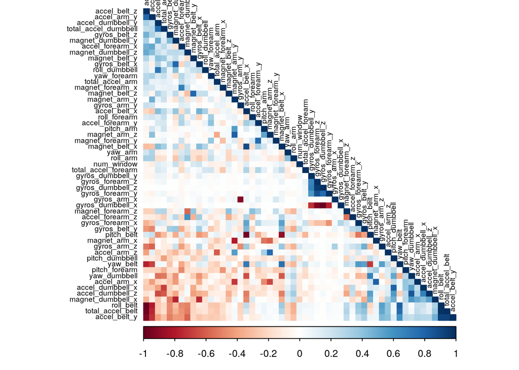

```r
corMatrix <- cor(TrainSet[, -54])
corrplot(corMatrix, order = "FPC", method = "color", type = "lower",
         tl.cex = 0.6, tl.col = 'black')
```

### Prediction Model

#### Decision Trees

A decision tree is a flowchart-like structure in which each internal node represents a “test” on an attribute (e.g. whether a coin flip comes up heads or tails), each branch represents the outcome of the test, and each leaf node represents a class label (decision taken after computing all attributes). The paths from root to leaf represent classification rules. Decision tree learning uses a decision tree (as a predictive model) to go from observations about an item (represented in the branches) to conclusions about the item’s target value (represented in the leaves). *Source:* [Wikipedia](https://en.wikipedia.org/wiki/Decision_tree_learning)

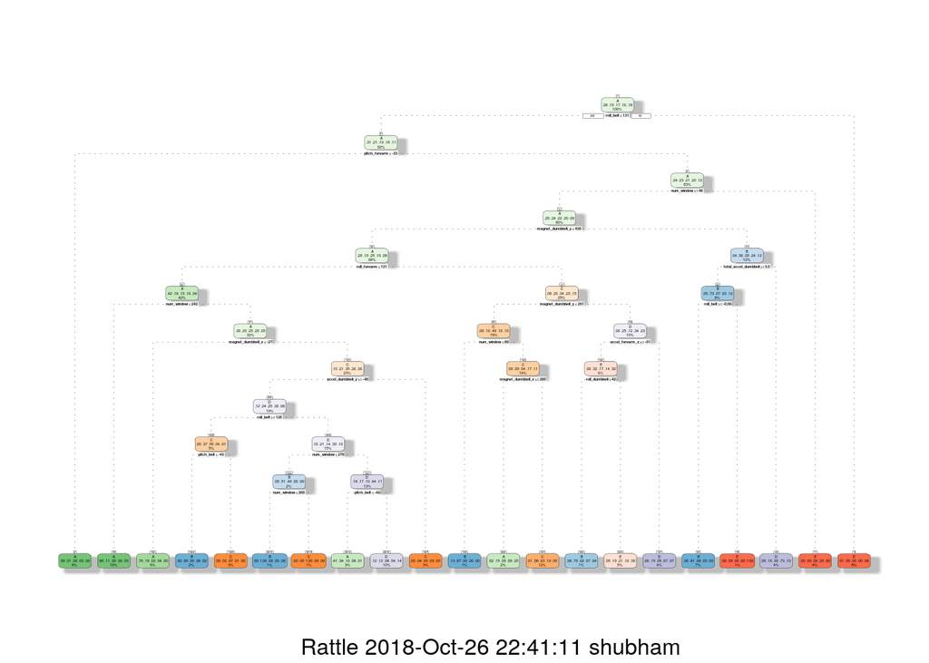

```r
modFitDecTree <- rpart(classe ~ ., data=TrainSet, method="class")
fancyRpartPlot(modFitDecTree)
```

```r
# prediction on Test dataset
predictDecTree <- predict(modFitDecTree, newdata=TestSet, type="class")
confMatDecTree <- confusionMatrix(predictDecTree, TestSet$classe)
confMatDecTree
```

```
## Confusion Matrix and Statistics
##
##           Reference
## Prediction    A    B    C    D    E
##          A 1494  271   53   84   60
##          B   49  608   32   22   23
##          C    9   58  816  153   71
##          D  102  138   56  606  141
##          E   20   64   69   99  787
##
## Overall Statistics
##
##                Accuracy : 0.7325
##                  95% CI : (0.721, 0.7438)
##     No Information Rate : 0.2845
##     P-Value [Acc > NIR] : < 2.2e-16
##
##                   Kappa : 0.66
##  Mcnemar's Test P-Value : < 2.2e-16
##
## Statistics by Class:
##
##                      Class: A Class: B Class: C Class: D Class: E
## Sensitivity            0.8925   0.5338   0.7953   0.6286   0.7274
## Specificity            0.8889   0.9735   0.9401   0.9112   0.9475
## Pos Pred Value         0.7615   0.8283   0.7371   0.5810   0.7575
## Neg Pred Value         0.9541   0.8969   0.9560   0.9261   0.9391
## Prevalence             0.2845   0.1935   0.1743   0.1638   0.1839
## Detection Rate         0.2539   0.1033   0.1387   0.1030   0.1337
## Detection Prevalence   0.3334   0.1247   0.1881   0.1772   0.1766
## Balanced Accuracy      0.8907   0.7536   0.8677   0.7699   0.8374
```

#### Random Forest

Random forests or random decision forests are an ensemble learning method for classification, regression and other tasks, that operate by constructing a multitude of decision trees at training time and outputting the class that is the mode of the classes (classification) or mean prediction (regression) of the individual trees. Random decision forests correct for decision trees’ habit of overfitting to their training set. *Source:* [Wikipedia](https://en.wikipedia.org/wiki/Random_forest)

```r
controlRF <- trainControl(method="cv", number=3, verboseIter=FALSE)
modFitRandForest <- train(classe ~ ., data=TrainSet, method="rf",
                          trControl=controlRF)
modFitRandForest$finalModel
```

```
##
## Call:
##  randomForest(x = x, y = y, mtry = param$mtry)
##                Type of random forest: classification
##                      Number of trees: 500
## No. of variables tried at each split: 27
##
##         OOB estimate of  error rate: 0.25%
## Confusion matrix:
##      A    B    C    D    E  class.error
## A 3904    1    0    0    1 0.0005120328
## B    9 2644    4    1    0 0.0052671181
## C    0    4 2392    0    0 0.0016694491
## D    0    0    8 2244    0 0.0035523979
## E    0    0    0    6 2519 0.0023762376
```

```r
# prediction on Test dataset
predictRandForest <- predict(modFitRandForest, newdata=TestSet)
confMatRandForest <- confusionMatrix(predictRandForest, TestSet$classe)
confMatRandForest
```

```
## Confusion Matrix and Statistics
##
##           Reference
## Prediction    A    B    C    D    E
##          A 1674    2    0    0    0
##          B    0 1136    1    0    2
##          C    0    1 1025    5    0
##          D    0    0    0  958    0
##          E    0    0    0    1 1080
##
## Overall Statistics
##
##                Accuracy : 0.998
##                  95% CI : (0.9964, 0.9989)
##     No Information Rate : 0.2845
##     P-Value [Acc > NIR] : < 2.2e-16
##
##                   Kappa : 0.9974
##  Mcnemar's Test P-Value : NA
##
## Statistics by Class:
##
##                      Class: A Class: B Class: C Class: D Class: E
## Sensitivity            1.0000   0.9974   0.9990   0.9938   0.9982
## Specificity            0.9995   0.9994   0.9988   1.0000   0.9998
## Pos Pred Value         0.9988   0.9974   0.9942   1.0000   0.9991
## Neg Pred Value         1.0000   0.9994   0.9998   0.9988   0.9996
## Prevalence             0.2845   0.1935   0.1743   0.1638   0.1839
## Detection Rate         0.2845   0.1930   0.1742   0.1628   0.1835
## Detection Prevalence   0.2848   0.1935   0.1752   0.1628   0.1837
## Balanced Accuracy      0.9998   0.9984   0.9989   0.9969   0.9990
```

### Applying the Selected Model to the Test Data

The accuracy of the 2 regression modeling methods above are:

1. Decision Tree : 0.7325
2. Random Forest : 0.998

Therefore,we select the Random Forest model to predict the 20 quiz results (testing dataset) as shown below.

```r
predictTEST <- predict(modFitRandForest, newdata=testing)
predictTEST
```

```
##  [1] B A B A A E D B A A B C B A E E A B B B
## Levels: A B C D E
```